# t-procedures for a Difference in Means

## A Mathematical Model

If it is reasonable to assume that the observations from each group are normally distributed, a \(t\)-distribution can be used to approximate the sampling distribution.

Conditions:

- Independent observations within and across groups
- Approximately normal distributions within each group
  - Sufficiently “large” samples
  - No extreme outliers

## Test Statistic

The test statistic for a \(t\)-test can be thought of as a ratio of how different the groups are to how different the observations in each group are.

The equation for the statistic is:

\[ T = \frac{\bar{x_1} - \bar{x_2}}{\sqrt{\frac{s_1^2}{n_1}} \sqrt{\frac{s_2^2}{n_2}}}\]

For the difference between exam A and exam B, the statistic is:

\[ T = \frac{75.1 - 72}{\sqrt{\frac{13.9^2}{58}} \sqrt{\frac{13.8^2}{55}}} = 1.21\]

## Hypothesis Test

When the null hypothesis is true and the model conditions are not violated, the \(t\)-statistic follows a \(t\)-distribution.

- The official formula for the degrees of freedom is quite complex, so instead you may use the smaller of \(min(n_1 - 1, n_2 - 1)\).

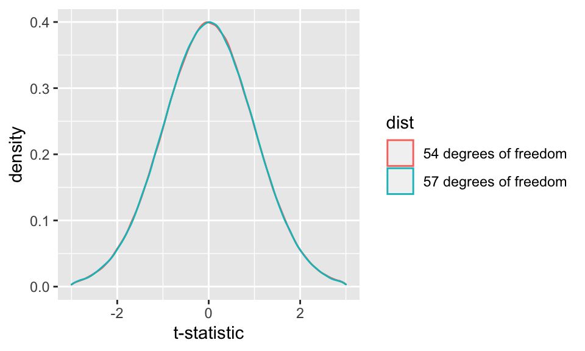

## p-value Calculation

1. Find test statistic on \(t\)-distribution
2. Find area of distribution as or more extreme than observed statistic, based on alternative hypothesis

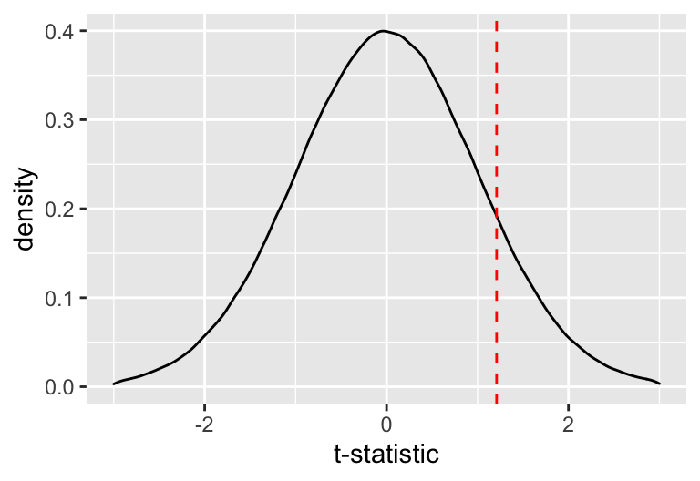

```r
1 - pt(1.21, df = 54)
```

```
## [1] 0.1157746
```

## Using the `t_test()` Function Instead

```r
classdata %>%
  t_test(m1 ~ exam,
         order = c("a", "b"),
         alternative = "greater",
         conf_int = FALSE)
```

```
## # A tibble: 1 x 4
##   statistic  t_df p_value alternative
##       <dbl> <dbl>   <dbl> <chr>
## 1      1.21  111.   0.115 greater
```

## Confidence Interval Calculation

A \(t\)-based confidence interval uses three numbers:

1. The observed statistic
2. The observed variability
3. A multiplier determining the width of the interval

These components are assembled as follows:

\[ \bar{x_1} - \bar{x_2} \pm t^* \cdot SE \]

- The value of \(t^*\) is determined from
  - the t-distribution with \(df = min(n_1 - 1, n_2 - 1)\)
  - the confidence level (e.g. 90%, 95%, 99%)

## Using the `t_test()` Function Instead

```r
classdata %>%
  t_test(m1 ~ exam,
         order = c("a", "b"),
         alternative = "greater",
         conf_int = TRUE,
         conf_level = 0.95)
```

```
## # A tibble: 1 x 6
##   statistic  t_df p_value alternative lower_ci upper_ci
##       <dbl> <dbl>   <dbl> <chr>          <dbl>    <dbl>
## 1      1.21  111.   0.115 greater        -1.17      Inf
```